# H06_daily: gap clock-hour repair

Targeted task-owned sensitivity repair and H06-D-G2B author gate

Published

August 12, 2026

**ImportantAnswer in brief**

The task-owned repair converted the five gap timing outcomes from their audited clock-hour source representation to the minute-scale interface expected by the frozen H06_daily adapter, after which the adapter converted them exactly once back to modeled clock hours. The repair changed only the 90 authorized gap timing cells. All 90 now pass the hard construct, support, fit, and estimability gates; visual review found reportable residual limitations but no gross residual failure.

The six gap 15-slot BH families are interpretable again. In the repaired near-eye all-available timing results, work/free day and previous-night sleep duration were BH-supported for all five outcomes; daily activity status was not BH-supported for any of the five. None of the five repaired predictor-by-site timing tests was BH-supported. These are observational, gap-timing-unaware sensitivity results and do not change the frozen primary daily estimates or the selected hourly main H06 analysis.

# 1 Exact repair boundary

The owner authorized a targeted H06_daily-only repair after the H06-D-G2A unit audit. No shared preparation file, other hypothesis, primary H06_daily frame, L10 mean result, MDER model or raw result, temporal GAMM, pre-sleep sensitivity, or hourly H06 artifact was changed.

The shared gap source stores the five outcomes in clock hours, including the declared signed L10 representation. The frozen H06_daily adapter expects a minute-scale input and divides by 60. The task-owned normalizer therefore multiplies only these gap-source values by 60 immediately before that frozen adapter. The modeled response is consequently the original clock-hour value, not clock hours divided by 60. Outcomes, rows, dates, sites, predictors, contrasts, sample roles, and response-family routes are unchanged.

Table 1: Targeted repair and preservation checks.

| Check | Expected | Observed | Verified |
| --- | --- | --- | --- |
| corrected gap clock cells | 90 | 90 | Yes |
| unaffected non-L10 cells preserved | 378 | 378 | Yes |
| replaced primary-gap raw tests | 30 | 30 | Yes |
| recomputed gap 15-slot families | 6 | 6 | Yes |
| primary families unchanged | 6 | 6 | Yes |
| L10 raw/BH slots remain named NA | 12 | 12 | Yes |
| MDER raw values unchanged | 12 | 12 | Yes |
| protected historical identities verified | 1011 | 1011 | Yes |
| frozen G2A output identities verified | 997 | 997 | Yes |

Exactly 378 non-L10 cells are frame-identical to the frozen grid. The repair replaced 30 primary-gap raw tests—five metrics by three predictors by two test types—and recomputed only the six gap families. The six primary families are unchanged. L10 remains the named unavailable slot 3. MDER remains frozen in slot 15; only its mathematically dependent gap-family BH fields could change.

# 2 Repaired near-eye gap timing results

The near-eye all-available repaired frames contain 708–777 participant-days, 137–141 participants, and all nine sites, depending on outcome and predictor. Effects are absolute clock-hour differences. For sleep duration, the effect is per additional hour of the prespecified day-specific sleep-duration term. Intervals are pointwise 95% confidence intervals; no simultaneous intervals are used.

Table 2: Repaired gap-timing-unaware near-eye timing associations.

| Predictor | Days | Participants | Sites | Difference in clock time, h (95% CI) | Raw p | BH q |
| --- | --- | --- | --- | --- | --- | --- |
| Midpoint of the brightest 10 hours |  |  |  |  |  |  |
| Work/free day | 777 | 141 | 9 | 0.66 (0.38 to 0.93) | <0.001 | <0.001 |
| Daily activity status | 729 | 137 | 9 | -0.20 (-0.53 to 0.13) | 0.234 | 0.335 |
| Previous-night sleep duration | 777 | 141 | 9 | 0.26 (0.17 to 0.35) | <0.001 | <0.001 |
| Midpoint of the darkest 10 hours |  |  |  |  |  |  |
| Work/free day | 777 | 141 | 9 | 0.50 (0.23 to 0.76) | <0.001 | <0.001 |
| Daily activity status | 729 | 137 | 9 | -0.27 (-0.61 to 0.07) | 0.121 | 0.227 |
| Previous-night sleep duration | 777 | 141 | 9 | 0.17 (0.06 to 0.27) | 0.002 | 0.004 |
| Mean timing of exposure above 250 lx melEDI |  |  |  |  |  |  |
| Work/free day | 751 | 141 | 9 | 0.27 (0.03 to 0.51) | 0.025 | 0.038 |
| Daily activity status | 708 | 137 | 9 | 0.12 (-0.16 to 0.40) | 0.410 | 0.473 |
| Previous-night sleep duration | 751 | 141 | 9 | 0.12 (0.04 to 0.20) | 0.003 | 0.005 |
| First light timing above 250 lx melEDI |  |  |  |  |  |  |
| Work/free day | 751 | 141 | 9 | 1.35 (1.01 to 1.70) | <0.001 | <0.001 |
| Daily activity status | 708 | 137 | 9 | -0.31 (-0.88 to 0.26) | 0.284 | 0.355 |
| Previous-night sleep duration | 751 | 141 | 9 | 0.44 (0.29 to 0.59) | <0.001 | <0.001 |
| Last light timing above 250 lx melEDI |  |  |  |  |  |  |
| Work/free day | 751 | 141 | 9 | -0.82 (-1.18 to -0.46) | <0.001 | <0.001 |
| Daily activity status | 708 | 137 | 9 | 0.48 (0.02 to 0.95) | 0.041 | 0.089 |
| Previous-night sleep duration | 751 | 141 | 9 | -0.16 (-0.30 to -0.02) | 0.030 | 0.034 |

BH q-values belong to separate 15-slot gap association families by predictor. Bold q-values meet the explicitly labelled BH q < 0.05 rule. Every row remains acceptable with a visual residual limitation.

Exact fitted samples for every complementary chest, paired/common, and dataset-common cell are retained in `artifacts/09_tables/H06_daily/H06_daily_gap_clock_repair_sample_summary.csv`; the corresponding 90 point estimates and pointwise intervals are in `artifacts/09_tables/H06_daily/H06_daily_gap_clock_repair_effects.csv`.

Across these five repaired timing outcomes:

- Free days were associated with later M10 midpoint, later L10 midpoint, later mean timing above 250 lx melEDI, later first timing above 250 lx melEDI, and earlier last timing above 250 lx melEDI. All five associations retained BH support.
- A longer previous-night sleep duration was associated with later M10 and L10 midpoints, later mean and first timing above 250 lx melEDI, and earlier last timing above 250 lx melEDI. All five associations retained BH support.
- Daily Active versus Sedentary status was not BH-supported for any of the five repaired outcomes. The last-timing contrast had raw p = 0.041 but BH q = 0.089, so it is not bolded and does not support a multiplicity-adjusted claim.

All wording describes associations with recorded day-level contexts. It does not imply causal effects or health outcomes.

## 2.1 Site heterogeneity

Table 3: BH-adjusted site-heterogeneity tests for the five repaired timing outcomes.

| Predictor | Heterogeneity BH q |
| --- | --- |
| Midpoint of the brightest 10 hours |  |
| Work/free day | 0.957 |
| Daily activity status | 0.546 |
| Previous-night sleep duration | 0.299 |
| Midpoint of the darkest 10 hours |  |
| Work/free day | 0.580 |
| Daily activity status | 0.321 |
| Previous-night sleep duration | 0.299 |
| Mean timing of exposure above 250 lx melEDI |  |
| Work/free day | 1.000 |
| Daily activity status | 0.587 |
| Previous-night sleep duration | 0.647 |
| First light timing above 250 lx melEDI |  |
| Work/free day | 0.580 |
| Daily activity status | 0.302 |
| Previous-night sleep duration | 0.299 |
| Last light timing above 250 lx melEDI |  |
| Work/free day | 0.377 |
| Daily activity status | 0.546 |
| Previous-night sleep duration | 0.769 |

No repaired timing heterogeneity q-value is below 0.05. The four HC3 timing interaction routes remain sensitivity-dependent regardless of p-value; no unqualified site-interaction claim is permitted.

No repaired timing predictor-by-site test was BH-supported. This does not establish identical associations across sites; it means the fitted heterogeneity block did not cross the prespecified multiplicity threshold.

# 3 Complete 15-slot gap families

Table 4: Completed gap-timing-unaware BH families after the targeted repair.

| Test | Named slots | Available raw tests | Named NA slots | BH-supported slots | Claim-eligible slots | Family valid |
| --- | --- | --- | --- | --- | --- | --- |
| Daily activity status |  |  |  |  |  |  |
| Association | 15 | 14 | 1 | 6 | 6 | Yes |
| Site heterogeneity | 15 | 14 | 1 | 3 | 3 | Yes |
| Previous-night sleep duration |  |  |  |  |  |  |
| Association | 15 | 14 | 1 | 13 | 13 | Yes |
| Site heterogeneity | 15 | 14 | 1 | 1 | 1 | Yes |
| Work/free day |  |  |  |  |  |  |
| Association | 15 | 14 | 1 | 10 | 10 | Yes |
| Site heterogeneity | 15 | 14 | 1 | 8 | 7 | Yes |

Each family retains all 15 named slots and uses stats::p.adjust with n = 15. Slot 3 (L10 mean) remains NA. Slot 15 (MDER) is frozen and is not counted as a new claim even if its derived q-value is below 0.05.

Across the complete gap families, 29 of the 39 estimable non-L10 association slots and 11 of the 39 estimable non-L10 site-heterogeneity slots have BH q-values below 0.05 and pass the H01-aligned hard gate. Site-interaction claims from the HC3 timing route remain explicitly sensitivity-dependent.

# 4 H01-aligned diagnostics

The residual rule was applied exactly as approved: centering, homoscedasticity, and gross normality were judged visually from residual-versus-fitted and normal Q-Q plots. Numeric summaries did not assign any verdict. A gross visual problem could fail a cell; none was observed.

Table 5: Final H01-aligned classification of the complete 468-cell non-L10 grid.

| Class | Cells | Gross visual failures | Hard-gate failures |
| --- | --- | --- | --- |
| Acceptable | 0 | 0 | 0 |
| Acceptable with limitations | 468 | 0 | 0 |
| Not acceptable | 0 | 0 | 0 |

After repairing the true unit/construct defect, all 468 non-L10 production cells are acceptable with limitations and none fails a hard gate. This does not mean the diagnostics are clean: each cell has a recorded visual residual limitation, and the sensitivity sidecars remain visible.

Table 6: Diagnostic and sensitivity sidecars for the 90 repaired cells.

| Classification | Cells | Overall hard-gate input |
| --- | --- | --- |
| HC3 Student-t additive effect stability |  |  |
| STABLE | 70 | No |
| SUBSTANTIAL_LIMITATION | 2 | No |
| HC3 gap-aware no-nugget AR additive stability |  |  |
| STABLE | 42 | No |
| SUBSTANTIAL_LIMITATION | 4 | No |
| UNRESOLVED_NUMERICAL_FAILURE | 21 | No |
| UNSTABLE | 5 | No |
| Mixed-model gap-aware AR disposition |  |  |
| NOT_TRIGGERED | 11 | No |
| UNRESOLVED_AR_NUMERICAL_FAILURE | 3 | No |
| UNRESOLVED_AR_SINGULAR | 1 | No |
| UNRESOLVED_POST_AR_RESIDUAL_DEPENDENCE | 3 | No |
| Participant/site deletion influence |  |  |
| STABLE | 67 | No |
| SUBSTANTIAL_LIMITATION | 19 | No |
| UNSTABLE | 4 | No |
| Manual residual review |  |  |
| REVIEW_LIMITATION | 90 | Only if FAIL_GROSS |

For the 72 HC3 cells, the additive Student-t comparison was stable in 70 and showed a substantial 1-to-less-than-2-SE shift in two. The gap-aware no-nugget AR additive sidecar was stable in 42, substantially shifted in four, unstable in five, and numerically unresolved in 21. For the 18 mixed-model mean-timing cells, AR was not triggered in 11; three had unresolved AR numerics, one was singular, and three retained post-AR residual dependence. Deletion influence was stable in 67 cells, a substantial limitation in 19, and unstable in four. Under the approved H01 architecture, these findings must be reported but do not fail an otherwise estimable cell.

The repaired residuals and fitted values reproduce the historical mis-scaled residual geometry after multiplication by 60 to within 1.3e-06 clock hours for fitted values and 7.9e-07 for standardized residuals. This scale-equivariance explains why the unit repair restores the construct without erasing the previously observed residual-shape limitations.

## 4.1 Residual review atlas

The ten audit atlases below show all 90 repaired cells in indexed order, nine cells per atlas. Within each atlas, panels run left-to-right and then top-to-bottom. The canonical cell index records outcome, placement, sample, predictor, plot SHA-256, paired source-data SHA-256, and cell-specific alt text. The atlas is a navigation aid; the individual cell plots are the full-resolution audit source.

Table 7: Residual atlas index.

| Atlas | Cells | Outcomes | Atlas SHA-256 |
| --- | --- | --- | --- |
| ATLAS 01 | 001–009 | Midpoint of the brightest 10 hours | 192a3414132b95fd7e197b2a6bf5c2837b90872c4e09302a2976468885dfbc64 |
| ATLAS 02 | 010–018 | Midpoint of the brightest 10 hours | 5a16517a289f786897e81e8fdef55e2bc57f8fa04db6dd1f9fff324f806d316e |
| ATLAS 03 | 019–027 | Midpoint of the darkest 10 hours | 120d5cab8ecfa5ed4643bde406abf73c02659372217dbb80a619154e97d5a4db |
| ATLAS 04 | 028–036 | Midpoint of the darkest 10 hours | 646dd9469ff674b2c30bc5a6e709ddc960c56e5bb15679a540ca83e78c454079 |
| ATLAS 05 | 037–045 | Mean timing of exposure above 250 lx melEDI | 7877a7685ac3bddbd0ffc0da7fbf01ebc710ded0b2e8c80dade6213769e9a3b2 |
| ATLAS 06 | 046–054 | Mean timing of exposure above 250 lx melEDI | aec133cf64645ede0a6c95e108016f817316fc003f7c70fddc4e90e0baa2ecf7 |
| ATLAS 07 | 055–063 | First light timing above 250 lx melEDI | e81fad622f5c9170ed99ae413587d1009426bed73851d69ed5240fc9561c7d3d |
| ATLAS 08 | 064–072 | First light timing above 250 lx melEDI | 60d147817775856d0b38f41b39f627a84707c0044dc524c46d065e9fe80b7dde |
| ATLAS 09 | 073–081 | Last light timing above 250 lx melEDI | 41d9a9fb370479c80e989021eb87f01445d18e0e21c22ab3a39f8465ead12879 |
| ATLAS 10 | 082–090 | Last light timing above 250 lx melEDI | d68c4f712d705e0793ff08c89fdd2aa6789cc81023118d6ef02419164da989ec |

### 4.1.1 ATLAS 01: cells 001–009

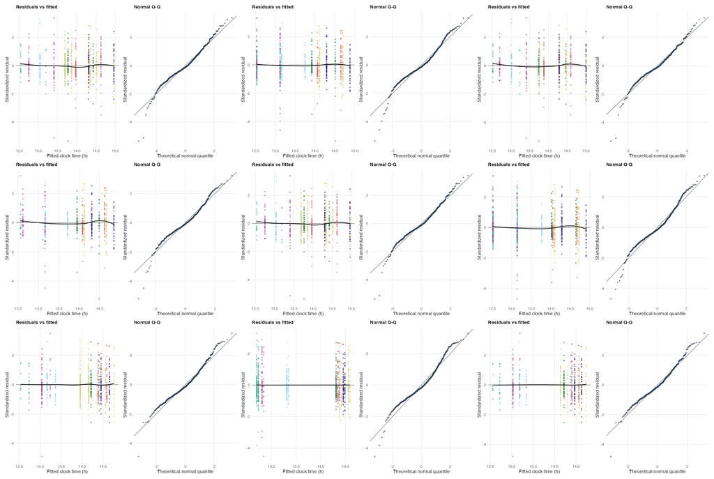

### 4.1.2 ATLAS 02: cells 010–018

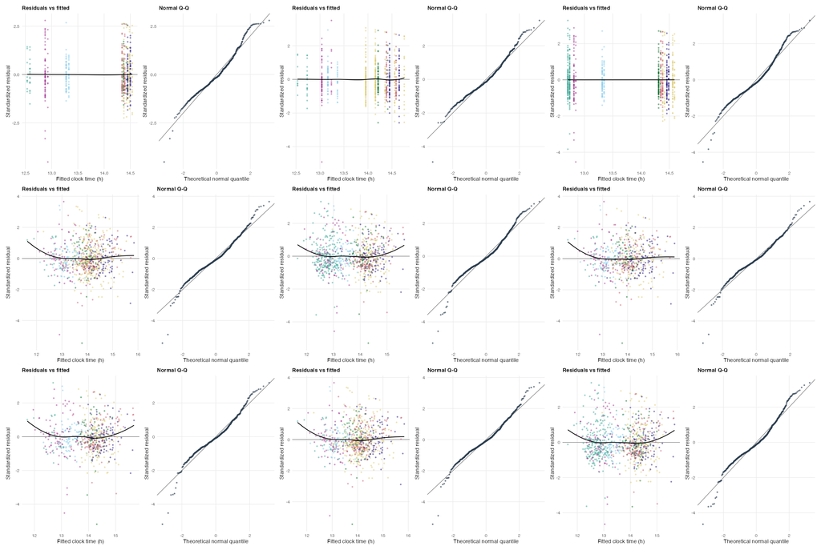

### 4.1.3 ATLAS 03: cells 019–027

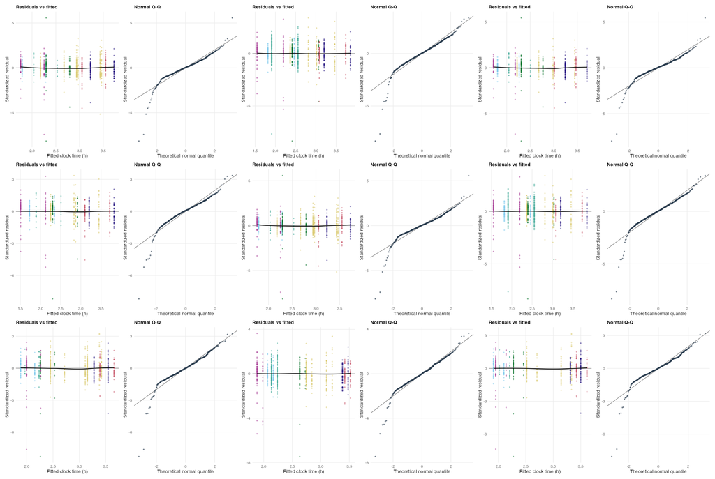

### 4.1.4 ATLAS 04: cells 028–036

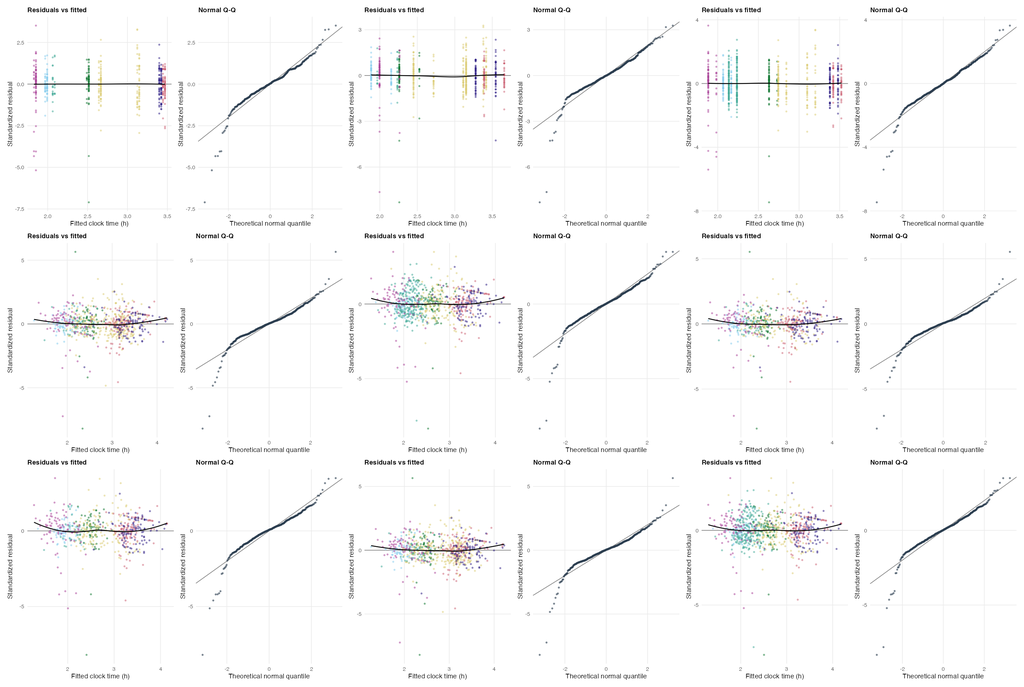

### 4.1.5 ATLAS 05: cells 037–045

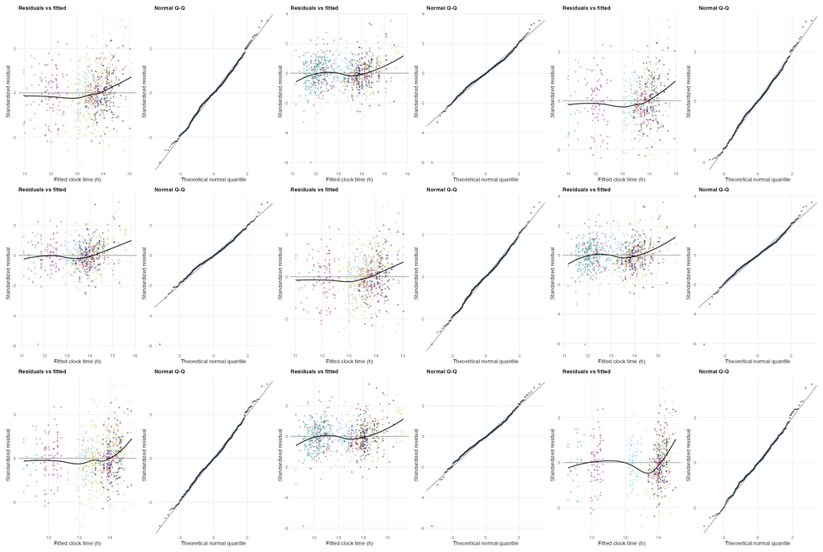

### 4.1.6 ATLAS 06: cells 046–054

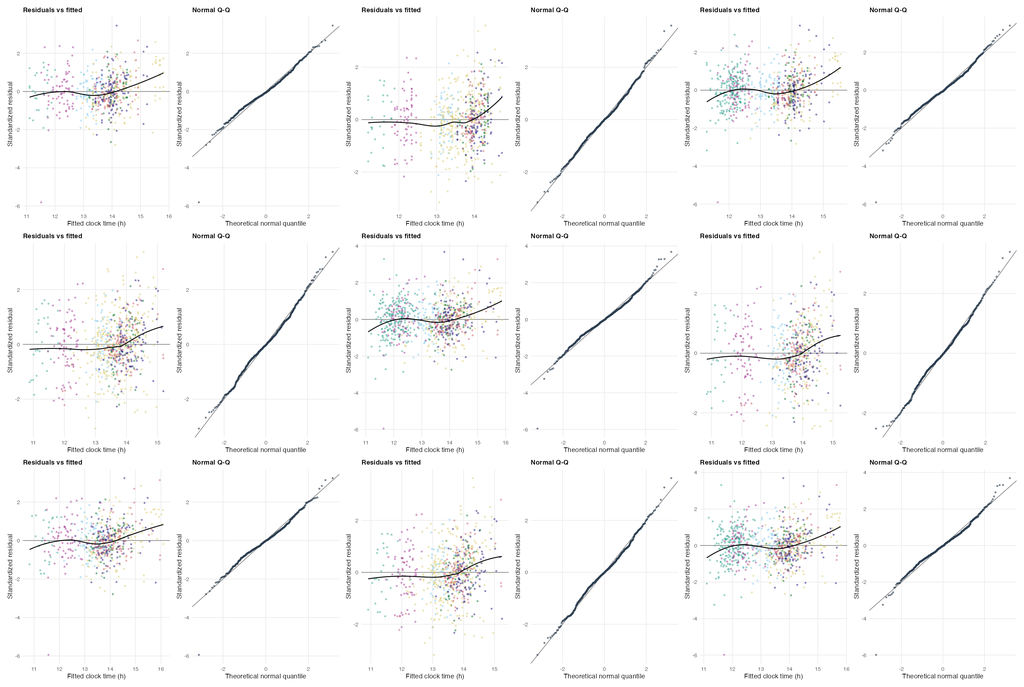

### 4.1.7 ATLAS 07: cells 055–063

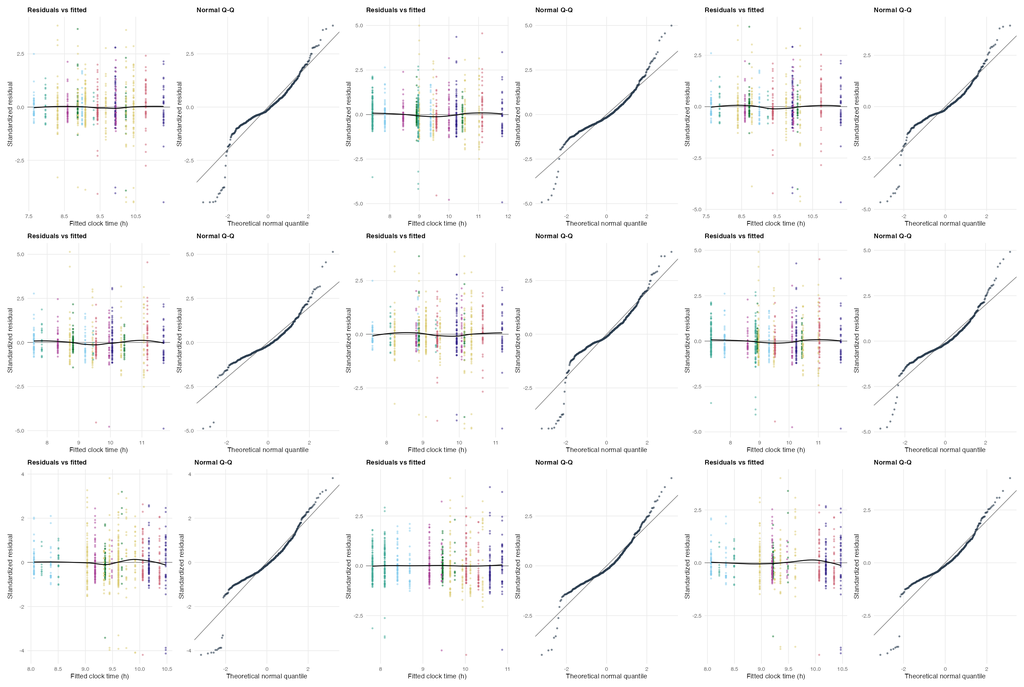

### 4.1.8 ATLAS 08: cells 064–072

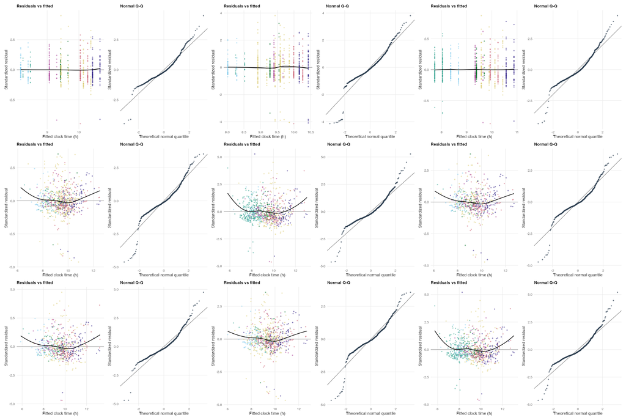

### 4.1.9 ATLAS 09: cells 073–081

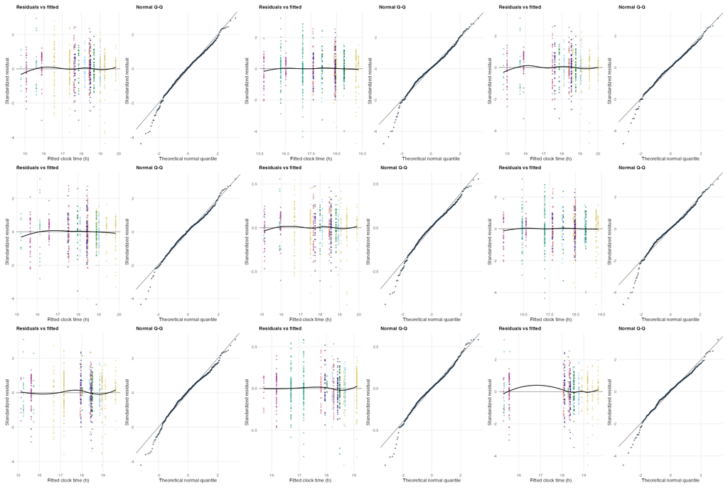

### 4.1.10 ATLAS 10: cells 082–090

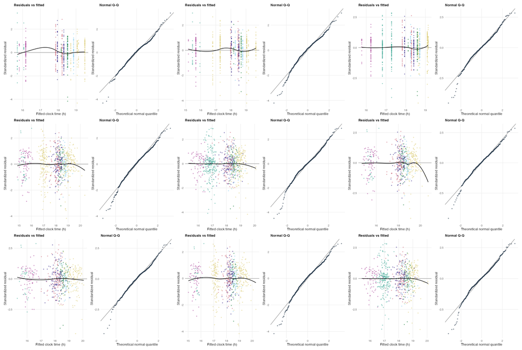

# 5 Scientific interpretation and comparison boundary

This repair retains the intended gap-timing-unaware sensitivity: it asks whether conclusions persist when the gap timing information is ignored while keeping the participant-day outcome definitions and predictor hierarchy. It does not rebuild shared preparation, alter the primary daily analysis, or make the daily and hourly H06 estimands numerically interchangeable.

The corrected p-values are scale-equivariant to the historical values within 9.9e-14 for raw p-values. That numerical similarity does not excuse the historical unit error: clock hours divided by 60 were not a valid reader-facing construct. The repaired frame and model objects are newly sealed, while the 378 unaffected cells remain frozen.

# 6 Reproducibility and preservation

The repair ran serially in R 4.6.1. The 90 repaired base cells and embedded sidecars took 69.3 seconds. The complete 12,837-refit participant/site deletion battery took 162.8 seconds, with no failed refit or repeated checkpoint failure. No bootstrap or simulation was run.

Final verification confirms:

- all 1,011 protected historical identities remain exact;
- all 997 frozen H06-D-G2A output identities remain exact;
- all 378 unaffected frame objects remain exact;
- the 30 repaired raw slots are the only replaced raw tests;
- the six gap families are the only recomputed BH families; and
- every output written by this amendment is under an H06_daily-owned path.

# 7 H06-D-G2B-GAP-CLOCK-REPAIR author stop gate

The targeted repair is complete and stops here for explicit author review. The recommended disposition is to accept the repaired gap clock-hour branch as the intended gap-timing-unaware sensitivity, with all visual, AR, response-family, influence, and timing-interaction limitations retained in the result language.

Acceptance of this gate would permit the coordinator to close the Stage 2 repair record. It does not by itself authorize Stage 3 reader-report writing, Stage 4 provenance writing, website integration, shared preparation edits, main-H06 changes, a commit, or a push.